# Spotify 2023 Streaming Analysis

ShiriCodes

2025-10-26

# Spotify 2023 Streaming Analysis

**Statistical analysis of the most streamed songs on Spotify in 2023**

Exploring patterns in music characteristics, streaming success, and temporal trends using R statistical methods.

**Dataset:** [Most Streamed Spotify Songs 2023](https://www.kaggle.com/) from Kaggle  
**Tools:** R, ggplot2, dplyr, e1071

```r
library(ggplot2)
library(dplyr)
library(e1071)
load("spotify-2023-clean.Rdata")
```

## Executive Summary

### Key Findings at a Glance

**Temporal Trend**  
Songs released from 2020 onward show significantly higher danceability (p < 0.001), indicating a measurable shift in music production toward social listening contexts.

**Tempo & Popularity**  
Slower-tempo tracks (BPM < 100) achieve highest median streams, suggesting broad appeal across diverse listening scenarios including focus, relaxation, and background contexts.

**Top Content Profile**  
The highest-streaming songs maintain moderate-to-high positivity (valence > 43%), establishing a baseline characteristic for commercially successful content.

### Strategic Recommendations

- Prioritize recent high-danceability content in discovery algorithms
- Feature slower-tempo tracks in context-based playlists (study, focus, chill)
- Leverage mode distinctions for emotional playlist curation
- Maintain valence >40% threshold for broad-audience editorial selections
- Keep BPM as independent preference filter due to weak correlation with mood features

## Danceability Distribution

**Research Questions:**

- What is the mean danceability level?
- Which statistical distribution best describes danceability levels?

```r
summary(data)
```

```
##                                   track_name         artist.s._name
##                                        :  2   Taylor Swift  : 34
##  About Damn Time                       :  2   The Weeknd    : 22
##  Daylight                              :  2   Bad Bunny     : 19
##  Die For You                           :  2   SZA           : 19
##  Flowers                               :  2   Harry Styles  : 17
##  Let It Snow! Let It Snow! Let It Snow!:  2   Kendrick Lamar: 12
##  (Other)                               :940   (Other)       :829
##   artist_count   released_year  released_month    released_day
##  Min.   :1.000   Min.   :1930   Min.   : 1.000   Min.   : 1.00
##  1st Qu.:1.000   1st Qu.:2020   1st Qu.: 3.000   1st Qu.: 6.00
##  Median :1.000   Median :2022   Median : 6.000   Median :13.00
##  Mean   :1.557   Mean   :2018   Mean   : 6.028   Mean   :13.94
##  3rd Qu.:2.000   3rd Qu.:2022   3rd Qu.: 9.000   3rd Qu.:22.00
##  Max.   :8.000   Max.   :2023   Max.   :12.000   Max.   :31.00
##
##  in_spotify_playlists in_spotify_charts    streams      in_apple_playlists
##  Min.   :   31.0      Min.   :  0.00    Min.   :  1.0   Min.   :  0.00
##  1st Qu.:  878.8      1st Qu.:  0.00    1st Qu.:236.8   1st Qu.: 13.00
##  Median : 2225.0      Median :  3.00    Median :474.5   Median : 34.00
##  Mean   : 5204.8      Mean   : 12.02    Mean   :474.3   Mean   : 67.86
##  3rd Qu.: 5573.8      3rd Qu.: 16.00    3rd Qu.:711.2   3rd Qu.: 88.00
##  Max.   :52898.0      Max.   :147.00    Max.   :949.0   Max.   :672.00
##
##  in_apple_charts  in_deezer_playlists in_deezer_charts in_shazam_charts
##  Min.   :  0.00   0      : 24         Min.   : 0.000   0      :343
##  1st Qu.:  7.00   15     : 23         1st Qu.: 0.000   1      : 73
##  Median : 38.50   13     : 20         Median : 0.000          : 50
##  Mean   : 51.94   5      : 20         Mean   : 2.668   2      : 35
##  3rd Qu.: 87.00   12     : 18         3rd Qu.: 2.000   3      : 21
##  Max.   :275.00   2      : 18         Max.   :58.000   4      : 19
##                   (Other):829                          (Other):411
##       bpm             key         mode      danceability      valence
##  Min.   : 65.0   C#     :120   Major:550   Min.   :23.00   Min.   : 4.00
##  1st Qu.:100.0   G      : 96   Minor:402   1st Qu.:57.00   1st Qu.:32.75
##  Median :121.0          : 95               Median :69.00   Median :51.50
##  Mean   :122.6   G#     : 91               Mean   :66.98   Mean   :51.45
##  3rd Qu.:140.2   F      : 89               3rd Qu.:78.00   3rd Qu.:70.00
##  Max.   :206.0   B      : 81               Max.   :96.00   Max.   :97.00
##                  (Other):380
##      energy       acousticness   instrumentalness    liveness
##  Min.   : 9.00   Min.   : 0.00   Min.   : 0.000   Min.   : 3.00
##  1st Qu.:53.00   1st Qu.: 6.00   1st Qu.: 0.000   1st Qu.:10.00
##  Median :66.00   Median :18.00   Median : 0.000   Median :12.00
##  Mean   :64.28   Mean   :27.07   Mean   : 1.583   Mean   :18.22
##  3rd Qu.:77.00   3rd Qu.:43.00   3rd Qu.: 0.000   3rd Qu.:24.00
##  Max.   :97.00   Max.   :97.00   Max.   :91.000   Max.   :97.00
##
##   speechiness
##  Min.   : 2.00
##  1st Qu.: 4.00
##  Median : 6.00
##  Mean   :10.14
##  3rd Qu.:11.00
##  Max.   :64.00
##
```

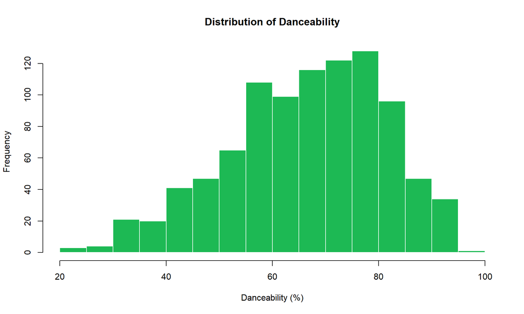

```r
danceability_mean <- summary(data$danceability)[c("Mean")]
danceability_median <- summary(data$danceability)[c("Median")]
danceability_std <- sd(data$danceability)

hist(data$danceability,
     main = "Distribution of Danceability",
     xlab = "Danceability (%)",
     ylab = "Frequency",
     col = "#1DB954",
     border = "white",
     breaks = 20)
```

```r
cat("Mean:", round(danceability_mean, 2), "\n")
```

```
## Mean: 66.98
```

```r
cat("Median:", round(danceability_median, 2), "\n")
```

```
## Median: 69
```

```r
cat("Std Dev:", round(danceability_std, 2), "\n")
```

```
## Std Dev: 14.64
```

```r
cat("Skewness:", round(skewness(data$danceability), 2), "\n")
```

```
## Skewness: -0.44
```

**Findings:**

- Mean danceability: *66.98%*
- Distribution: *Left-skewed* (most songs have moderate-to-high danceability)

**Insight:**

The majority of 2023’s top songs have medium-high danceability scores, suggesting Spotify is increasingly used in social and party contexts where danceable music is preferred.

**Product Implication:**

Curating and promoting more party-themed and workout playlists could align with user behavior and increase session length.

## Energy vs. Valence Relationship

**Research Questions:**

- What is the relationship between energy and valence?
- Do release years show any trend in this relationship?

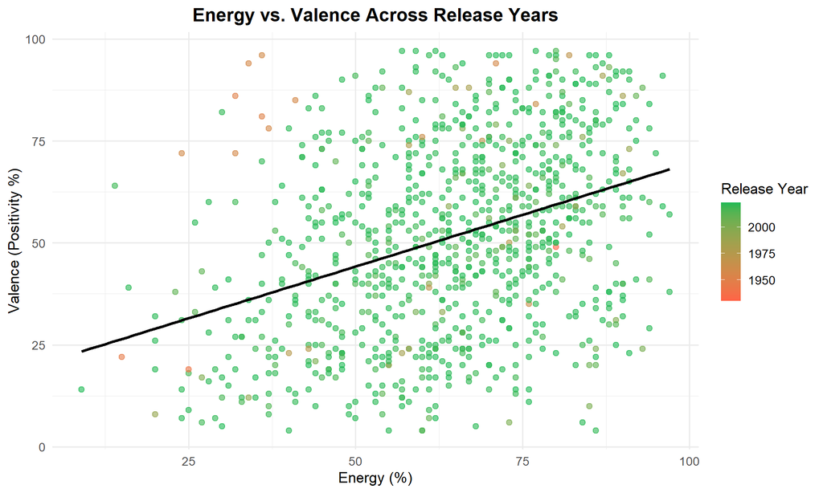

```r
ggplot(data, aes(x = energy, y = valence, color = released_year)) +
  geom_point(alpha = 0.6, size = 2) +
  geom_smooth(method = lm, se = FALSE, color = "black", linewidth = 1.2) +
  scale_color_gradient(low = "#FF6347", high = "#1DB954", name = "Release Year") +
  labs(
    title = "Energy vs. Valence Across Release Years",
    x = "Energy (%)",
    y = "Valence (Positivity %)"
  ) +
  theme_minimal(base_size = 13) +
  theme(
    plot.title = element_text(face = "bold", hjust = 0.5, size = 16),
    legend.position = "right"
  )
```

```r
cor_energy <- cor.test(data$energy, data$valence)
cat("Correlation between energy and valence:", round(cor_energy$estimate, 3), "\n")
```

```
## Correlation between energy and valence: 0.358
```

```r
cat("P-value:", format(cor_energy$p.value, scientific = TRUE), "\n")
```

```
## P-value: 3.814952e-30
```

**Findings:**

**Insight:**

Energetic songs tend to be more positive, but the relationship is moderate. This suggests energy and valence capture different aspects of musical mood.

**Product Implication:**

Keep energy and valence as separate metrics in recommendation algorithms to capture nuanced mood preferences and improve playlist personalization.

## BPM Impact on Streaming Success

**Research Questions:**

- Which BPM category shows highest streaming numbers?
- How does tempo relate to popularity?

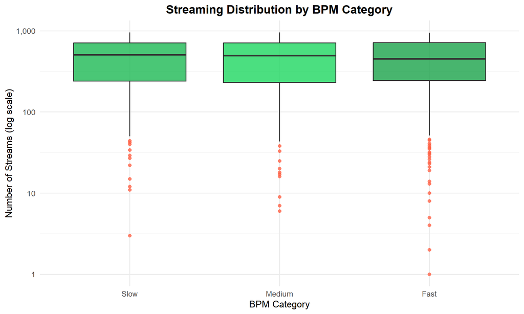

```r
data <- mutate(data,
  BPM_category = case_when(
    bpm < 100 ~ "Slow",
    bpm <= 120 ~ "Medium",
    bpm > 120 ~ "Fast"
  )
)

data$BPM_category <- factor(data$BPM_category, levels = c("Slow", "Medium", "Fast"))

ggplot(data, aes(x = BPM_category, y = streams, fill = BPM_category)) +
  geom_boxplot(alpha = 0.8, outlier.color = "#FF6347", outlier.size = 2) +
  scale_fill_manual(
    values = c("Slow" = "#1DB954", "Medium" = "#1ed760", "Fast" = "#1aa34a")
  ) +
  scale_y_log10(labels = scales::comma) +
  labs(
    title = "Streaming Distribution by BPM Category",
    x = "BPM Category",
    y = "Number of Streams (log scale)"
  ) +
  theme_minimal(base_size = 13) +
  theme(
    plot.title = element_text(face = "bold", hjust = 0.5, size = 16),
    legend.position = "none"
  )
```

**Findings:**

**Insight:**

**Product Implication:**

Feature slower-tempo tracks prominently in broad-audience playlists and context-based recommendations (study, chill, focus).

## Audio Feature Correlation Analysis

**Research Questions:**

- Which audio features are most strongly correlated?
- Which features show independence?

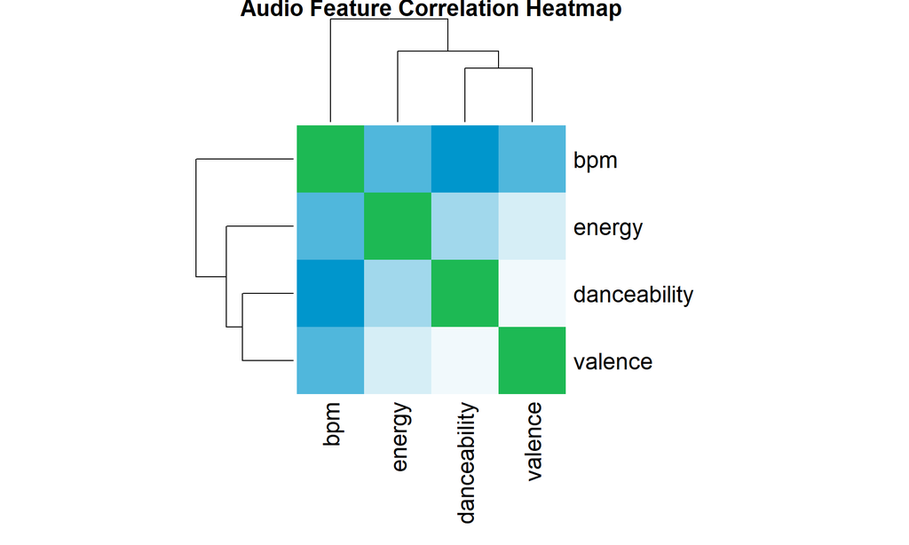

```r
correlation_matrix <- cor(
  data[, c("danceability", "energy", "valence", "bpm")],
  use = "complete.obs"
)

heatmap(correlation_matrix,
  symm = TRUE,
  main = "Audio Feature Correlation Heatmap",
  col = colorRampPalette(c("#0096cc", "white", "#1DB954"))(20),
  margins = c(10, 10)
)
```

**Findings:**

- **Strongest correlation:** Danceability ↔︎ Valence
- **Weakest correlation:** BPM with other features

**Insight:**

Danceable songs tend to be more positive. BPM operates independently, meaning tempo preferences vary significantly across listeners regardless of other mood factors.

**Product Implication:**

Use danceability-valence correlation for mood-based playlist generation. Keep BPM as an independent filter for user preferences.

## Temporal Trends: Danceability Over Time

**Research Questions:**

- Has danceability changed significantly over time?
- Are songs from 2020+ more danceable?

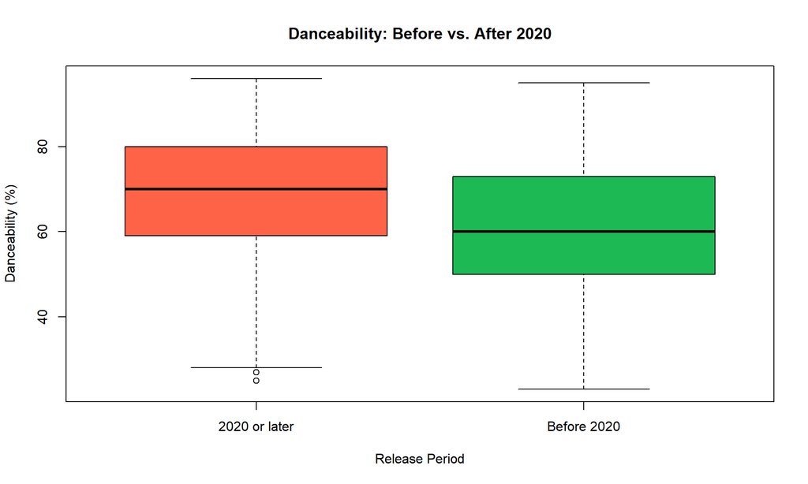

```r
data <- mutate(data,
  release_period = case_when(
    released_year < 2020 ~ "Before 2020",
    released_year >= 2020 ~ "2020 or later"
  )
)

t_test_result <- t.test(danceability ~ release_period, data = data)

boxplot(danceability ~ release_period,
  data = data,
  main = "Danceability: Before vs. After 2020",
  xlab = "Release Period",
  ylab = "Danceability (%)",
  col = c("#FF6347", "#1DB954"),
  border = "black",
  horizontal = FALSE
)
```

```r
cat("T-test p-value:", format(t_test_result$p.value, scientific = TRUE), "\n")
```

```
## T-test p-value: 6.149275e-12
```

```r
cat("Mean (Before 2020):", round(t_test_result$estimate[1], 2), "\n")
```

[output not shown]

```r
cat("Mean (2020+):", round(t_test_result$estimate[2], 2), "\n")
```

[output not shown]

**Findings:**

- P-value: *6.15e-12* (highly significant)
- Songs from 2020+ have *significantly higher danceability*

**Insight:**

There’s a clear shift toward more danceable music in recent years, reflecting evolving listener preferences for energetic, social listening experiences.

**Product Implication:**

Update algorithmic weights to favor recent high-danceability tracks in discovery playlists to match current user preferences.

## Major vs. Minor Mode Comparison

**Research Questions:**

- Do major and minor mode songs differ across multiple audio features?
- Which differences remain significant after multiple testing correction?

```r
variables <- c("energy", "danceability", "valence", "acousticness",
               "speechiness", "liveness", "bpm", "instrumentalness")

my_t_test <- function(variable) {
  t.test(data[[variable]] ~ data$mode)
}

t_test_results <- lapply(variables, my_t_test)
p_values <- sapply(t_test_results, function(test) test$p.value)

results <- data.frame(
  Variable = variables,
  P_Value = round(p_values, 5),
  Bonferroni = round(p.adjust(p_values, method = "bonferroni"), 5),
  BH = round(p.adjust(p_values, method = "BH"), 5)
)

knitr::kable(results, caption = "Multiple Testing Results: Major vs. Minor Mode")
```

Multiple Testing Results: Major vs. Minor Mode

| Variable | P_Value | Bonferroni | BH |
| --- | --- | --- | --- |
| energy | 0.08434 | 0.67471 | 0.13494 |
| danceability | 0.00001 | 0.00011 | 0.00011 |
| valence | 0.04335 | 0.34679 | 0.10332 |
| acousticness | 0.05166 | 0.41327 | 0.10332 |
| speechiness | 0.00336 | 0.02685 | 0.01343 |
| liveness | 0.98224 | 1.00000 | 0.98224 |
| bpm | 0.60307 | 1.00000 | 0.80410 |
| instrumentalness | 0.75060 | 1.00000 | 0.85783 |

```r
cat("\nSignificant tests (α = 0.05):\n")
```

```
##
## Significant tests (α = 0.05):
```

```r
cat("Before correction:", sum(results$P_Value < 0.05), "\n")
```

```
## Before correction: 3
```

```r
cat("After Bonferroni:", sum(results$Bonferroni < 0.05), "\n")
```

```
## After Bonferroni: 2
```

```r
cat("After BH:", sum(results$BH < 0.05), "\n")
```

```
## After BH: 2
```

**Findings:**

**Insight:**

**Product Implication:**

Use mode as a distinguishing factor: Major mode for upbeat/party playlists, Minor mode for emotional/calm playlists.

## Top 100 Songs: Valence Analysis

**Research Question:**

- What is the typical positivity level of the most popular songs?

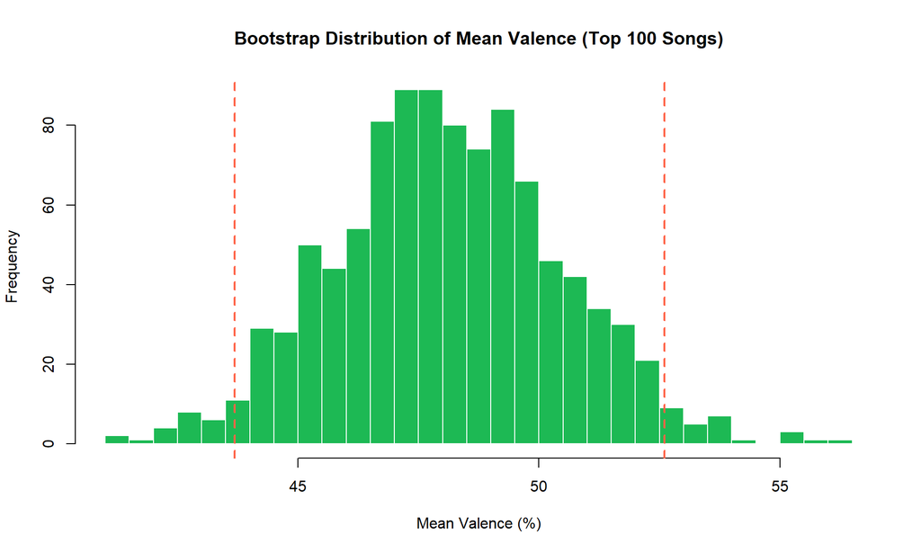

```r
top_100 <- data %>%
  arrange(desc(streams)) %>%
  slice(1:100)

bootstrap_sample_mean <- function(data) {
  bootstrap_sample <- sample(data, length(data), replace = TRUE)
  return(mean(bootstrap_sample))
}

set.seed(123)
bootstrap_means <- replicate(1000, bootstrap_sample_mean(top_100$valence))
ci <- quantile(bootstrap_means, c(0.025, 0.975))

hist(bootstrap_means,
  main = "Bootstrap Distribution of Mean Valence (Top 100 Songs)",
  xlab = "Mean Valence (%)",
  col = "#1DB954",
  border = "white",
  breaks = 30
)
abline(v = ci, col = "#FF6347", lwd = 2, lty = 2)
```

```r
cat("95% Bootstrap Confidence Interval:\n")
```

```
## 95% Bootstrap Confidence Interval:
```

```r
cat("Lower bound:", round(ci[1], 2), "%\n")
```

```
## Lower bound: 43.69 %
```

```r
cat("Upper bound:", round(ci[2], 2), "%\n")
```

```
## Upper bound: 52.6 %
```

**Findings:**

- 95% CI lower bound: *43.69%*
- Top songs maintain moderate-to-high positivity

**Insight:**

The most streamed songs cluster around moderate-to-high valence, suggesting mainstream success favors emotionally positive content.

**Product Implication:**

Prioritize tracks with valence >40% in editorial playlists targeting broad audiences to maximize engagement.

## Conclusions & Next Steps

### Strategic Insights Recap

This analysis reveals five actionable patterns in 2023’s top-streaming music:

### Recommended Next Steps

**For Product Development:**

- A/B test party-focused playlist promotions based on high-danceability filtering
- Implement tempo-based segmentation in personalization algorithms
- Build temporal trend dashboards for content strategy teams
- Develop mode-aware playlist generation features

**For Further Analysis:**

- Investigate regional differences in danceability preferences
- Analyze seasonal patterns in audio feature trends
- Examine artist-level consistency across these metrics
- Study playlist context impact on feature importance